# SPAM and Trees

Matt Richey

October 12, 2016

```r
library(tidyverse)
library(tree)
```

Predict SPAM values. Need train/test data. We will use cross-validated tree with pruning

Read in the SPAM data set (from UCI)

```r
spam.df <- read.csv("SPAM.csv",header=T)
head(spam.df)
```

```
##   IsSpam make address  all X3d  our over remove internet order mail
## 1   TRUE 0.00    0.64 0.64   0 0.32 0.00   0.00     0.00  0.00 0.00
## 2   TRUE 0.21    0.28 0.50   0 0.14 0.28   0.21     0.07  0.00 0.94
## 3   TRUE 0.06    0.00 0.71   0 1.23 0.19   0.19     0.12  0.64 0.25
## 4   TRUE 0.00    0.00 0.00   0 0.63 0.00   0.31     0.63  0.31 0.63
## 5   TRUE 0.00    0.00 0.00   0 0.63 0.00   0.31     0.63  0.31 0.63
## 6   TRUE 0.00    0.00 0.00   0 1.85 0.00   0.00     1.85  0.00 0.00
##   receive will people report addresses free business email  you credit
## 1    0.00 0.64   0.00   0.00      0.00 0.32     0.00  1.29 1.93   0.00
## 2    0.21 0.79   0.65   0.21      0.14 0.14     0.07  0.28 3.47   0.00
## 3    0.38 0.45   0.12   0.00      1.75 0.06     0.06  1.03 1.36   0.32
## 4    0.31 0.31   0.31   0.00      0.00 0.31     0.00  0.00 3.18   0.00
## 5    0.31 0.31   0.31   0.00      0.00 0.31     0.00  0.00 3.18   0.00
## 6    0.00 0.00   0.00   0.00      0.00 0.00     0.00  0.00 0.00   0.00
##   your font zero money hp hpl george Six50 lab labs telnet EighF57 data
```

[output cut: 27 more lines]

```r
spam.df <- mutate(spam.df,IsSpam=factor(ifelse(IsSpam=="TRUE",1,0)))
with(spam.df,table(IsSpam))
```

```
## IsSpam
##    0    1
## 2788 1813
```

```r
str(spam.df$IsSpam)
```

```
##  Factor w/ 2 levels "0","1": 2 2 2 2 2 2 2 2 2 2 ...
```

Build train and test data

```r
nn <- nrow(spam.df)
train <- sample(1:nn,nn/2,rep=F)
spamTrain.df <- spam.df[train,]
spamTest.df <- spam.df[-train,]
```

Our first tree…make is sorta deep since we’re going to prune it later

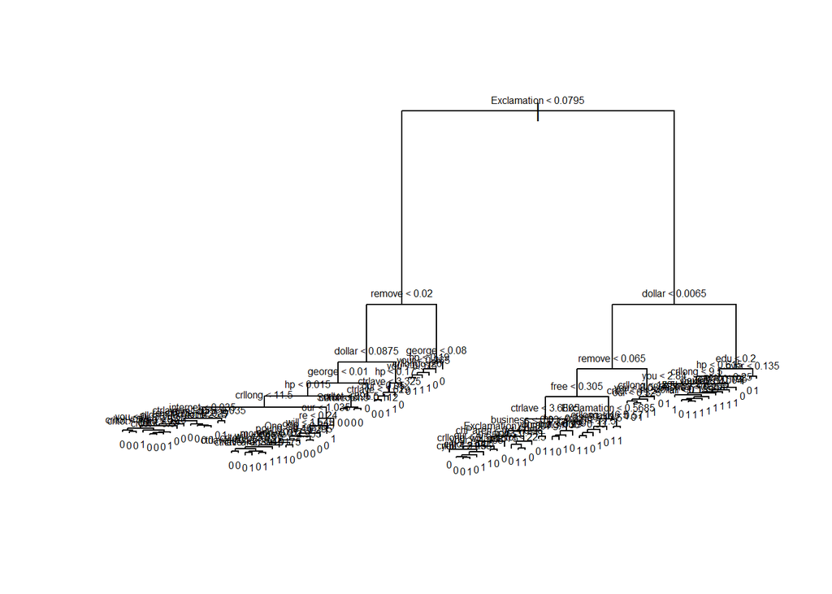

```r
spam.tree <- tree(IsSpam~.,data=spamTrain.df,
                  control=tree.control(nrow(spamTrain.df),mindev=0.001))
plot(spam.tree)
text(spam.tree,cex=0.5)
```

Cross validate to find the optimal size

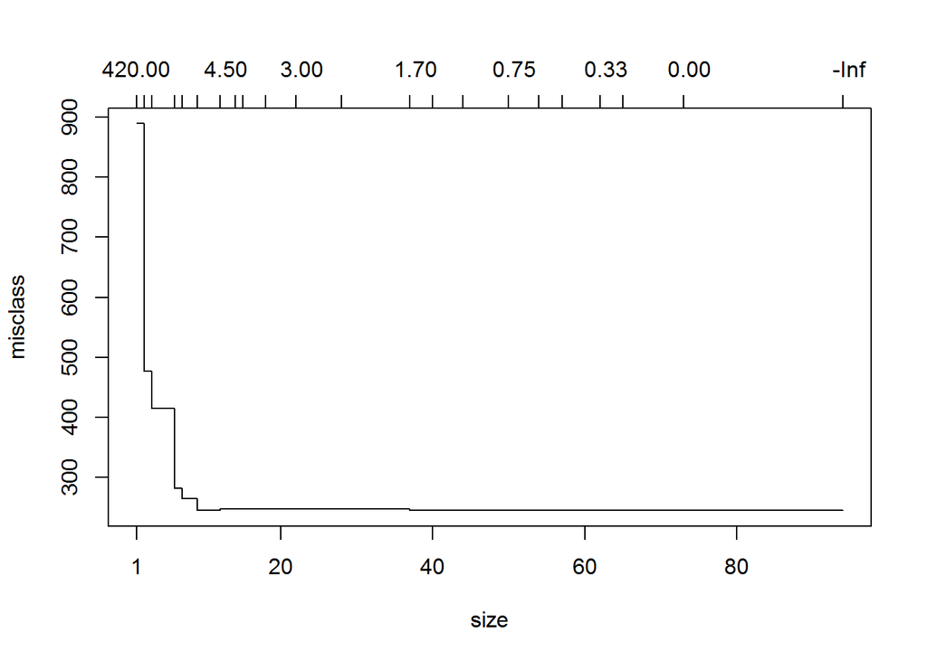

```r
spam.cv <- cv.tree(spam.tree,FUN=prune.misclass)
plot(spam.cv)
```

```r
spam.cv
```

```
## $size
##  [1] 94 73 65 62 57 54 50 44 40 37 28 22 18 15 14 12  9  7  6  3  2  1
##
## $dev
##  [1] 245 245 245 245 245 245 245 245 245 245 247 248 248 248 247 247 245
## [18] 265 282 415 477 889
##
## $k
##  [1]        -Inf   0.0000000   0.2500000   0.3333333   0.4000000
##  [6]   0.6666667   0.7500000   1.0000000   1.5000000   1.6666667
## [11]   2.7777778   3.0000000   3.5000000   3.6666667   4.0000000
## [16]   4.5000000   7.0000000  11.5000000  17.0000000  49.3333333
## [21]  60.0000000 421.0000000
##
## $method
## [1] "misclass"
##
## attr(,"class")
## [1] "prune"         "tree.sequence"
```

Dig out the optimal values..need to be careful here to make sure getting the optimal value I like to reverse the values to make sure we get smallest

```r
sz <- rev(spam.cv$size)
(best.sz <- sz[which.min(rev(spam.cv$dev))])
```

```
## [1] 9
```

Prune the tree and plot it.

```r
spam.prune=prune.tree(spam.tree,best=best.sz)
spam.prune
```

```
## node), split, n, deviance, yval, (yprob)
##       * denotes terminal node
##
##  1) root 2300 3069.00 0 ( 0.61348 0.38652 )
##    2) Exclamation < 0.0795 1333 1110.00 0 ( 0.85371 0.14629 )
##      4) remove < 0.02 1241  784.20 0 ( 0.90411 0.09589 )
##        8) dollar < 0.0875 1175  605.10 0 ( 0.92851 0.07149 )
##         16) george < 0.01 866  551.50 0 ( 0.90300 0.09700 ) *
##         17) george > 0.01 309    0.00 0 ( 1.00000 0.00000 ) *
##        9) dollar > 0.0875 66   91.25 1 ( 0.46970 0.53030 ) *
##      5) remove > 0.02 92   85.01 1 ( 0.17391 0.82609 ) *
##    3) Exclamation > 0.0795 967 1151.00 1 ( 0.28232 0.71768 )
##      6) dollar < 0.0065 490  679.30 0 ( 0.50408 0.49592 )
##       12) remove < 0.065 393  523.50 0 ( 0.61578 0.38422 )
##         24) free < 0.305 292  326.20 0 ( 0.75342 0.24658 )
##           48) ctrlave < 3.6805 247  222.00 0 ( 0.83401 0.16599 ) *
##           49) ctrlave > 3.6805 45   55.80 1 ( 0.31111 0.68889 ) *
##         25) free > 0.305 101  105.90 1 ( 0.21782 0.78218 ) *
##       13) remove > 0.065 97   39.39 1 ( 0.05155 0.94845 ) *
##      7) dollar > 0.0065 477  201.80 1 ( 0.05451 0.94549 ) *
```

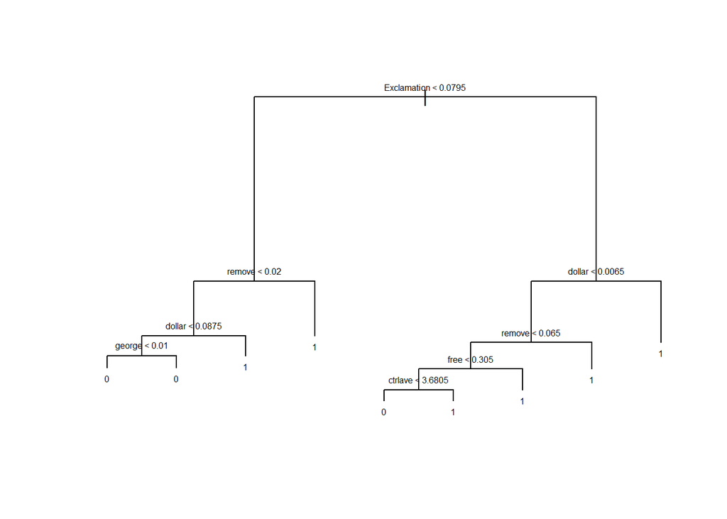

```r
plot(spam.prune)
text(spam.prune,cex=0.5)
```

Now we can make predictions on the Test data

```r
preds.test <- predict(spam.prune,newdata=spamTest.df,type="class")
table(preds.test)
```

```
## preds.test
##    0    1
## 1429  872
```

This will give you the probability of each class..Use this for an ROC curve or threshholding in general

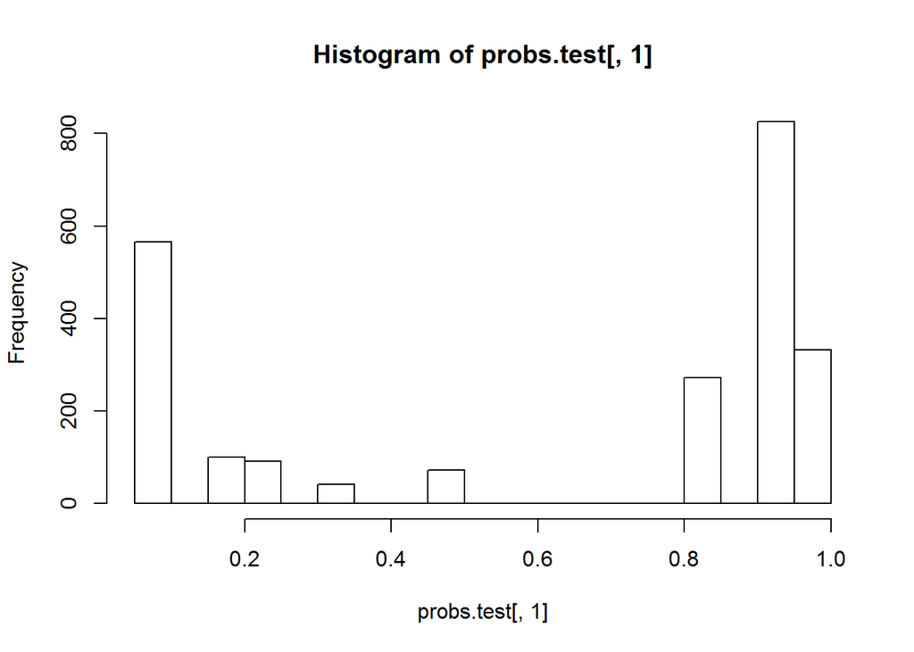

```r
probs.test <- predict(spam.prune,newdata=spamTest.df,type="vector")
hist(probs.test[,1],breaks=25)
```

How well did we do?

```r
with(spamTest.df,table(preds.test,IsSpam))
```

```
##           IsSpam
## preds.test    0    1
##          0 1286  143
##          1   91  781
```

```r
with(spamTest.df,mean(preds.test!=IsSpam))
```

```
## [1] 0.1016949
```

```r
preds.train <- predict(spam.prune,newdata=spamTrain.df,type="class")
with(spamTrain.df,table(preds.train,IsSpam))
```

```
##            IsSpam
## preds.train    0    1
##           0 1297  125
##           1  114  764
```

```r
with(spamTrain.df,mean(preds.train!=IsSpam))
```

```
## [1] 0.103913
```

## Bootstrap the data

```r
m.train <- nrow(spamTrain.df)
m.test <- nrow(spamTest.df)
B <- 40
bootVals <- matrix(nrow=m.test,ncol=B)
for(b in 1:B){
  print(b)
    boots <- sample(m.train,m.train,rep=T)
    spamBoot.df <- spamTrain.df[boots,]
    spam.tree <- tree(IsSpam~.,data=spamBoot.df,
                      control=tree.control(nrow(spamBoot.df),
                                           mindev=0.005))
    ##For demo purposes...I'm not cross validating.
    ##Assume depth of 15
    # spam.cv <- cv.tree(spam.tree)
    # sz <- rev(spam.cv$size)
    # bs <- sz[which.min(rev(spam.cv$dev))]
    bs<-15
    spam.prune=prune.misclass(spam.tree,best=bs)
    ###
    preds.test <- predict(spam.prune,
                           newdata=spamTest.df,
                           type="class")
    bootVals[,b] <-as.numeric(as.character(preds.test))
}
```

```
## [1] 1
## [1] 2
## [1] 3
## [1] 4
## [1] 5
## [1] 6
## [1] 7
## [1] 8
## [1] 9
## [1] 10
## [1] 11
## [1] 12
## [1] 13
## [1] 14
## [1] 15
```

[output cut: 25 more lines]

```r
dim(bootVals)
```

```
## [1] 2301   40
```

Now we can see how well boot strapping did. First we take the mean of hte row, then compare with 1/2.

```r
vals <- apply(bootVals,1,mean)
preds.boot <- as.numeric(vals>0.5)
with(spamTest.df,table(IsSpam,preds.boot))
```

```
##       preds.boot
## IsSpam    0    1
##      0 1318   59
##      1  122  802
```

```r
with(spamTest.df,mean(IsSpam != preds.boot))
```

```
## [1] 0.07866145
```

This can be done (better) with the built in library/function randomForest.

```r
library(randomForest)
p <- ncol(spamTrain.df)-1

spam.bag <- randomForest(IsSpam~.,
                         data=spamTrain.df,
                         #mtry=sqrt(p), ## For Random Forest
                         mtry=p, ##For BAG
                         ntree=100)
preds.bag <- predict(spam.bag,newdata=spamTest.df)
with(spamTest.df,table(IsSpam,preds.bag))
```

```
##       preds.bag
## IsSpam    0    1
##      0 1328   49
##      1   80  844
```

```r
with(spamTest.df,mean(IsSpam!=preds.bag))
```

```
## [1] 0.05606258
```

This shows the OOB error rate, the False Positive, and False Negative Error rates as a function of the number of trees.

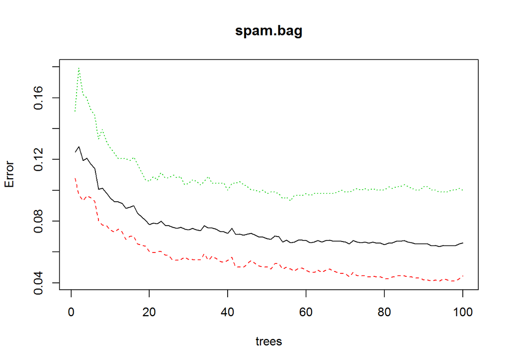

```r
plot(spam.bag)
```

We can see how the random forest works by looking at its output. Among other things, we can see the OOB confusion matrix and error rates.

```r
spam.bag
```

```
##
## Call:
##  randomForest(formula = IsSpam ~ ., data = spamTrain.df, mtry = p,      ntree = 100)
##                Type of random forest: classification
##                      Number of trees: 100
## No. of variables tried at each split: 57
##
##         OOB estimate of  error rate: 6.61%
## Confusion matrix:
##      0   1 class.error
## 0 1348  63  0.04464918
## 1   89 800  0.10011249
```

Look at variable importance, that is, how much of does each variable contribute to the decrease in the Error Rate (Gini Factor) at each split.

Turn importance into a data frame for plotting.

```r
vv<-spam.bag$importance
(varImp.df<-data.frame(var=as.character(row.names(vv)),GiniDec=vv[,1]))
```

```
##                     var     GiniDec
## make               make   5.4415203
## address         address   3.0780269
## all                 all   2.7405219
## X3d                 X3d   1.7968864
## our                 our  18.1851444
## over               over   4.1266821
## remove           remove 119.0887620
## internet       internet   6.2724148
## order             order   6.0553116
## mail               mail   7.9779913
## receive         receive   5.0087397
## will               will   9.6965335
## people           people   3.6725274
## report           report   2.4361608
## addresses     addresses   1.0210026
## free               free  43.5610225
## business       business   9.4180115
## email             email   6.9960832
## you                 you  20.9540020
## credit           credit   3.3209303
## your               your  22.9722521
## font               font   1.2456611
## zero               zero  13.0570848
## money             money  21.1013729
## hp                   hp  53.1729885
## hpl                 hpl   4.0820539
## george           george  13.5453132
## Six50             Six50   6.8308621
## lab                 lab   0.3664810
## labs               labs   1.2059617
## telnet           telnet   0.1755454
## EighF57         EighF57   0.5690447
## data               data   4.0286727
## Four15           Four15   0.3537727
## Eighty5         Eighty5   1.2936841
## technology   technology   4.5560160
## One999           One999   8.3909965
## parts             parts   0.4727427
## pm                   pm   4.0459927
## direct           direct   0.5036906
## cs                   cs   0.6324538
## meeting         meeting   5.5758556
## original       original   0.9256380
## project         project   1.3454862
## re                   re   5.7416382
## edu                 edu  22.0340760
## table             table   0.1427245
## conference   conference   1.2959758
## Semicolon     Semicolon   4.2655521
## chParen         chParen  13.9612346
## Bracket         Bracket   0.6553363
## Exclamation Exclamation 301.0525843
## dollar           dollar 166.8370181
## pound             pound   1.3549984
## ctrlave         ctrlave  55.1175877
## crllong         crllong  39.2043820
## crltot           crltot  26.6928107
```

Put the variable variable in order of importance.

```r
varOrder<-varImp.df %>%
  arrange(GiniDec) %>%
  with(var)
```

Fix the factors in the order of importance.

```r
varImp.df<-varImp.df %>%
  mutate(var=factor(var,levels=varOrder))
```

Plot it….

[figure not shown]

```r
ggplot(varImp.df[1:20,])+
  geom_bar(aes(x=var,GiniDec),stat="identity",fill="red",color="black",
  width=0.5)+
  scale_y_continuous("Gini Decrease")+
  coord_flip()+
  ggtitle("Top Twenty Variables in SPAM")
```

## Computing Out of Bag error

- Goal: Using our “by hand” bootstrap, compute the OOB error rate on the spamTrain data. How close does this come to predicting the the test error rate computed on spamTest?
- Extra: Also compute the OOB False Positive and False Negative rates. This should be easy.
- Extra Extra: Plot these rates as a function of hte number of trees used int the bootstrap. Doing so will recreate the plot of the random forest.

*Plan*: As we boot strap, keep track of the OOB values as the test data. After creating the boot strap tree, predict on the OOB values. Store the results in a matrix